# COVID19 Data Near Kosciusko County

Compiled by Dr. Ryan Johnson using data from Smith et al. (2020) based on reports from state and local health agencies by way of Guidotti and Ardia (2020).

Last updated Thursday, April 22, 2021

#### All counts will be reported as per 80,000 because that is roughly the population of Kosciusko County.

# Indiana State Data

### Hospitalizations - Indiana

Because hospitalizations are smoother than cases or deaths, we present the data with a line graph below:

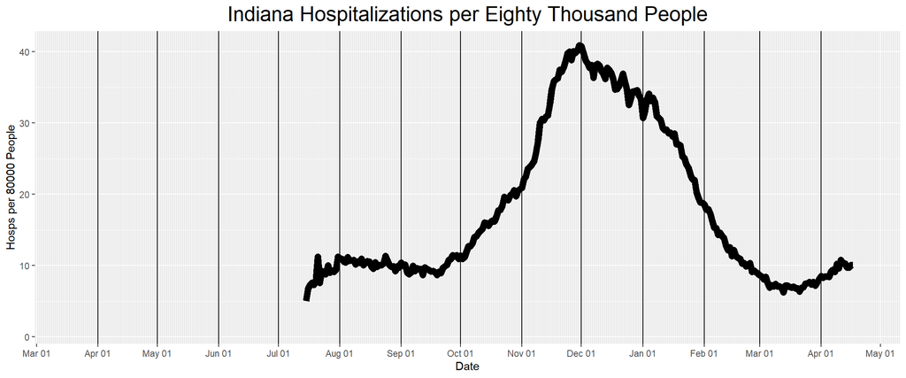

### Available ICU Beds

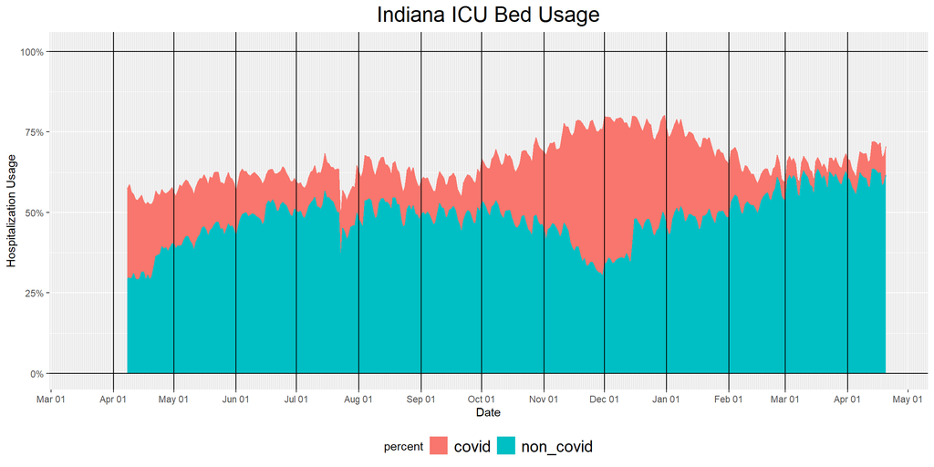

### Hospitals Accross the US with over 90% ICU beds in use

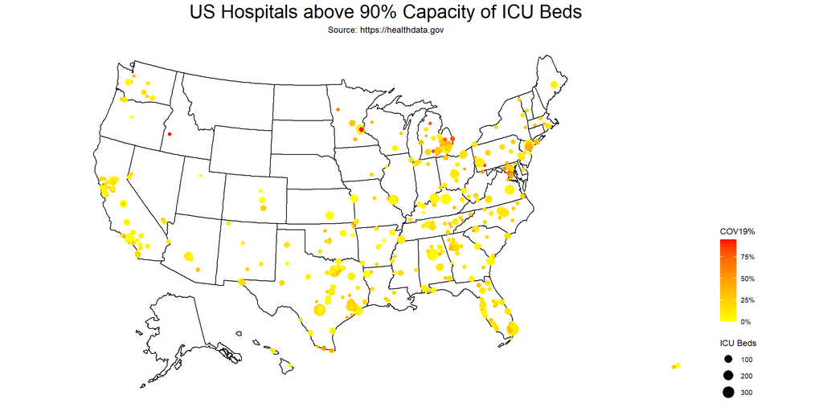

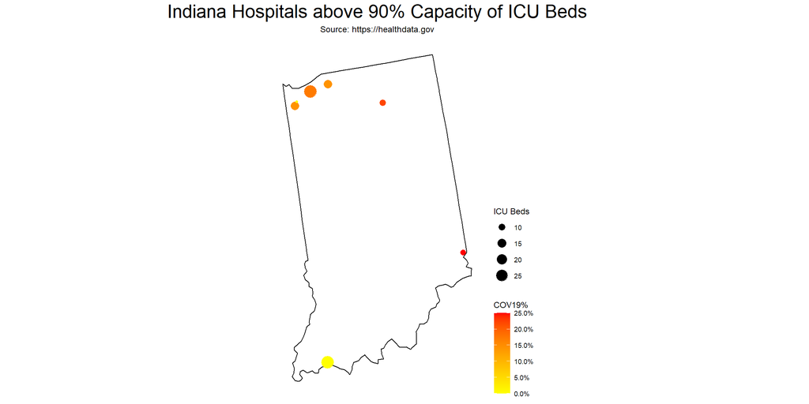

Hospitals in Indiana With Over 90% ICU Beds In Use

The numbers below are all 7-day averages

| Hospital Name | City | Total ICU Beds | Percent In Use | Percent COVID19 |
| --- | --- | --- | --- | --- |
| ST ELIZABETH DEARBORN HOSPITAL | LAWRENCEBURG | 8.0 | 92% | 25% |
| KOSCIUSKO COMMUNITY HOSPITAL | WARSAW | 9.0 | 92% | 22% |
| FRANCISCAN HEALTH CROWN POINT | CROWN POINT | 14.0 | 100% | 14% |
| VIBRA HOSPITAL OF NORTHWESTERN INDIANA | CROWN POINT | 6.0 | 100% | 0% |
| NORTHWEST HEALTH-LA PORTE | LA PORTE | 14.0 | 100% | 14% |
| NORTHWEST HEALTH- PORTER | VALPARAISO | 29.7 | 100% | 17% |
| WOMEN'S HOSPITAL THE | NEWBURGH | 29.6 | 100% | 0% |

Source: https://healthdata.gov

# Vaccines

## Statewide vaccine percentages

The following map shows percentages of adults who have had at least one vaccine shot. Percentages are based on population census data from 10-11 years ago.

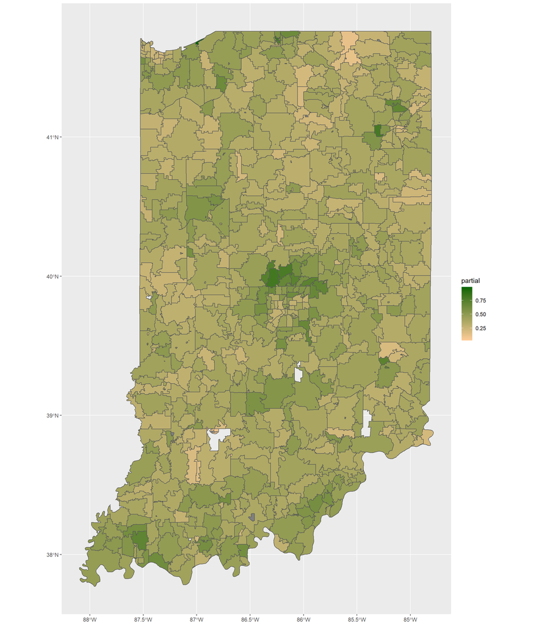

## Regional vaccine percentages

The following map shows percentages of adults who have had at least one vaccine shot. Percentages are based on population census data from 10-11 years ago.

The regio below extends from Plymouth (46563) in the West to Columbia City (46725) in the East.

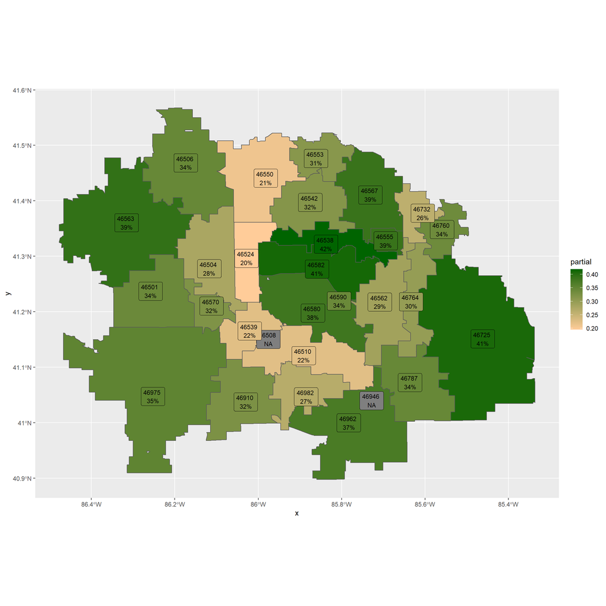

### Cases - Indiana

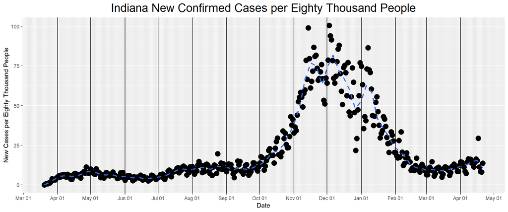

### Percentage of Positive Tests

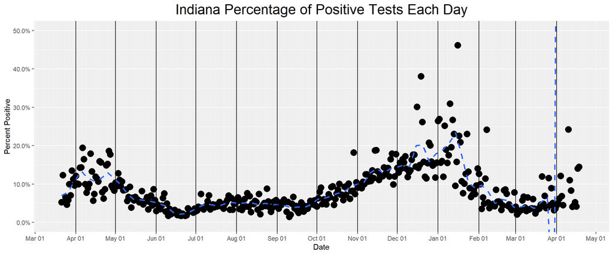

### Deaths - Indiana

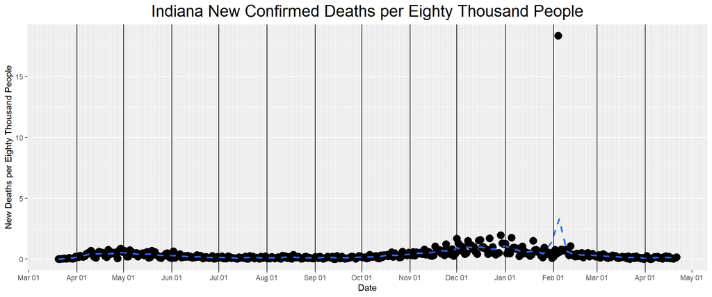

# Kosciusko Data

Note that the y-axis scales of these graphs are different than the state-level data.

### Cases - Kosciusko

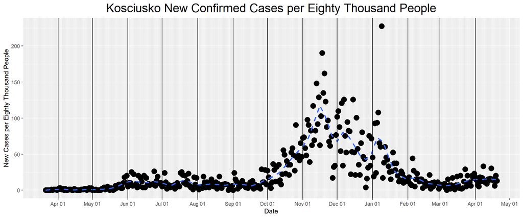

### Deaths - Kosciusko

Note that if the number of deaths below is more than the official count according to Kosciusko county, that is most likely because our data source is also counting non-residents of Kosciusko county who have died in Koscisusko county.

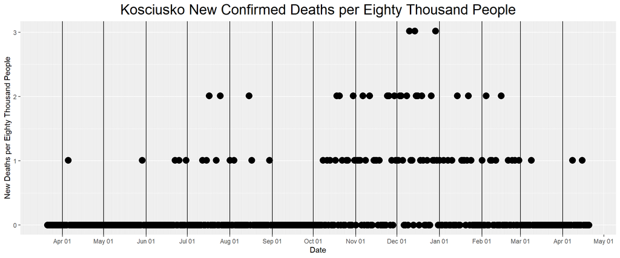

# Indiana Outbreaks

The coloring scheme for the map below is based on a combination of new cases per captita in the past week and positivity for unique indivuals in the previous week. The coloring scheme is relative, it will always color the worst county pure red and the best county white.

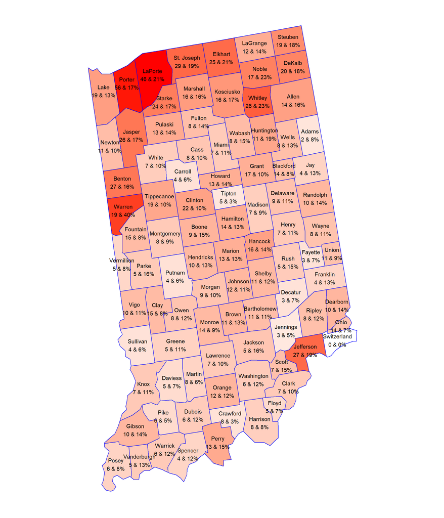

Note that the y-axis scales of these graphs are different than other sections.

### Cases - Outbreaks in Indiana

The first chart is a comparison of smoothed weighted averages. The second chart is the actual data.

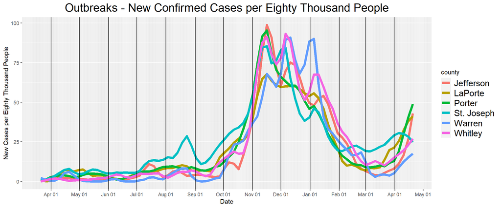

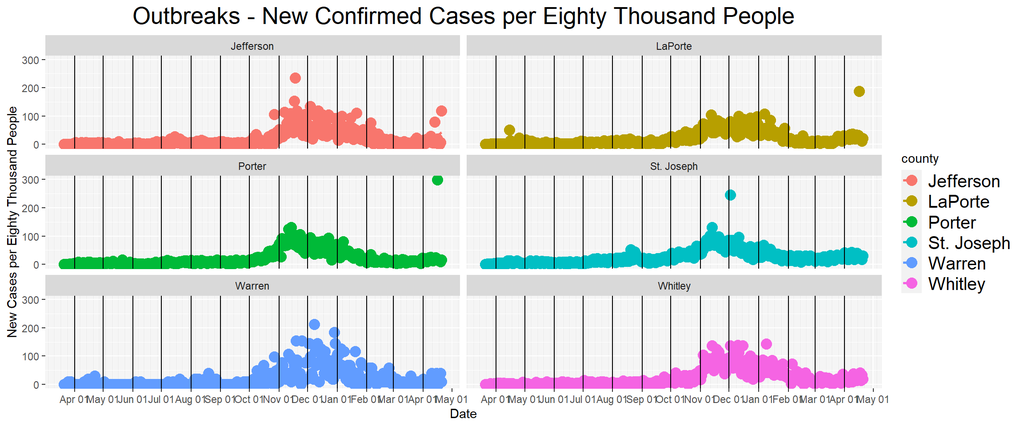

### Deaths - Outbreaks in Indiana

The first chart is a comparison of smoothed weighted averages. The second chart is the actual data.

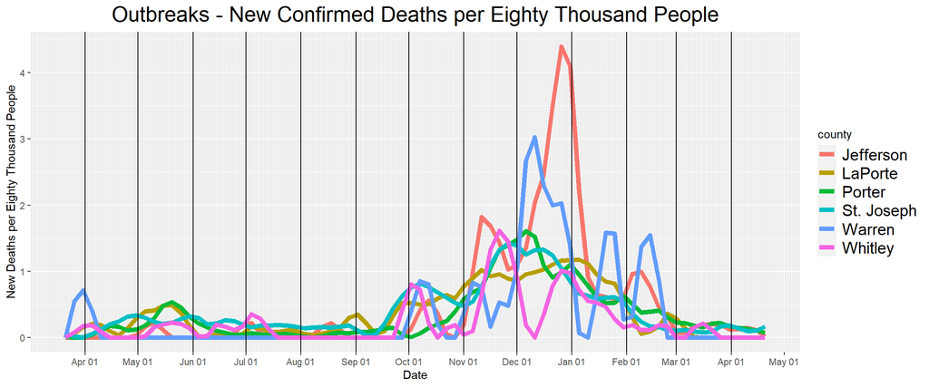

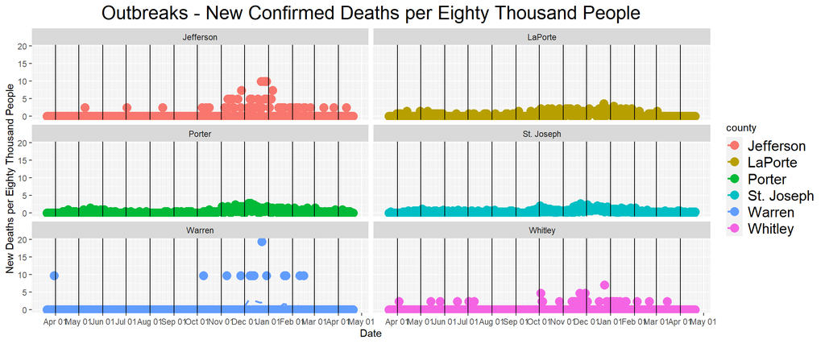

# Neighboring Counties

Note that the y-axis scales of these graphs are different than other sections.

### Cases - Counties Neighboring Kosciusko

The first chart is a comparison of smoothed weighted averages. The second chart is the actual data.

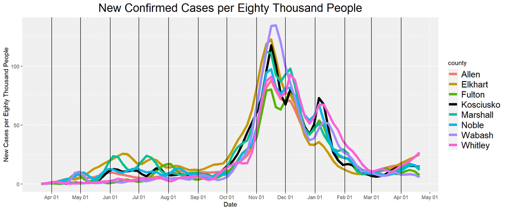

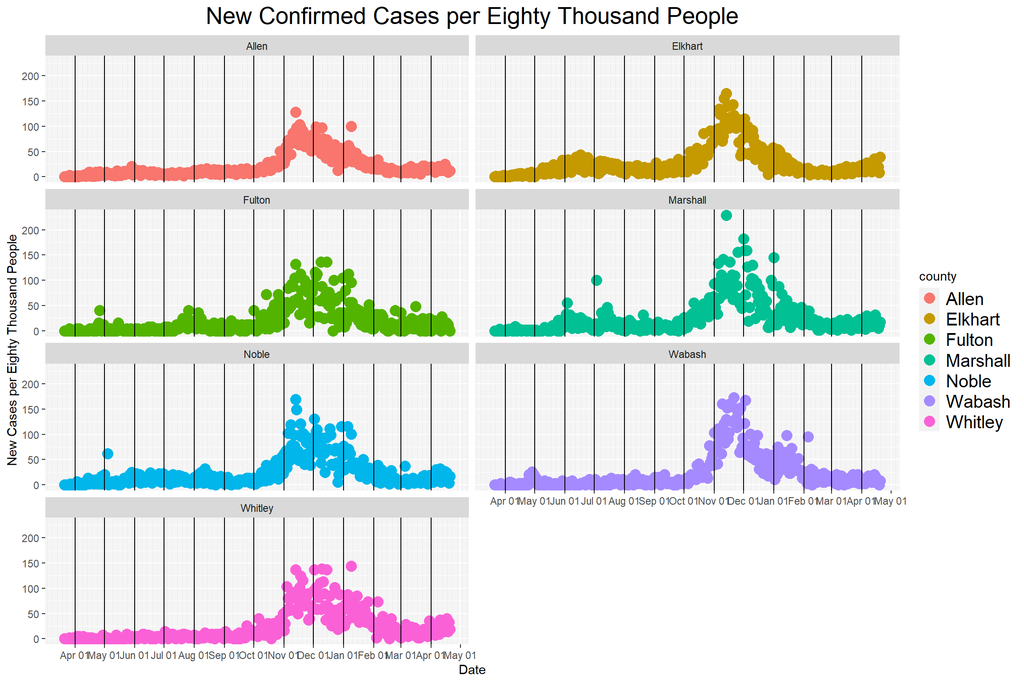

### Deaths - Counties Neighboring Kosciusko

The first chart is a comparison of smoothed weighted averages. The second chart is the actual data.

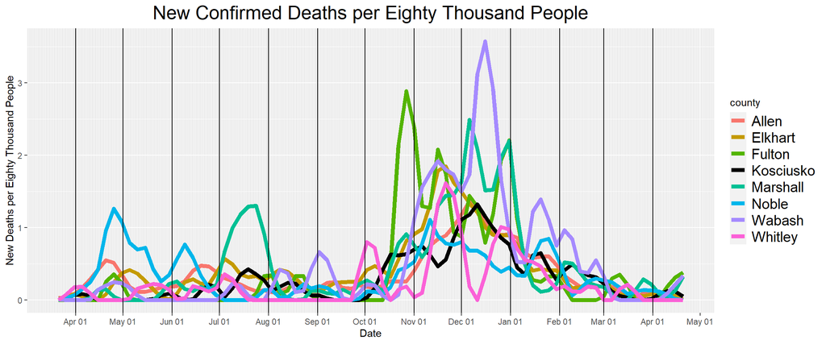

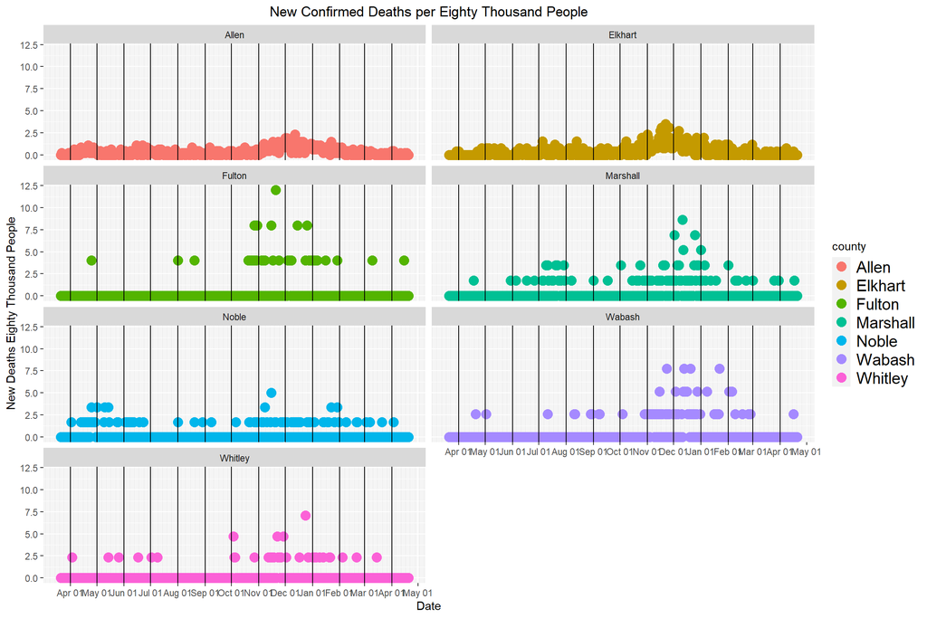

# Neighboring States Data

Note that the y-axis scales of these graphs are different than other sections.

### Cases - States Neighboring Indiana

The first plot is a comparison of smoothed weighted averages. The second is the actual data.

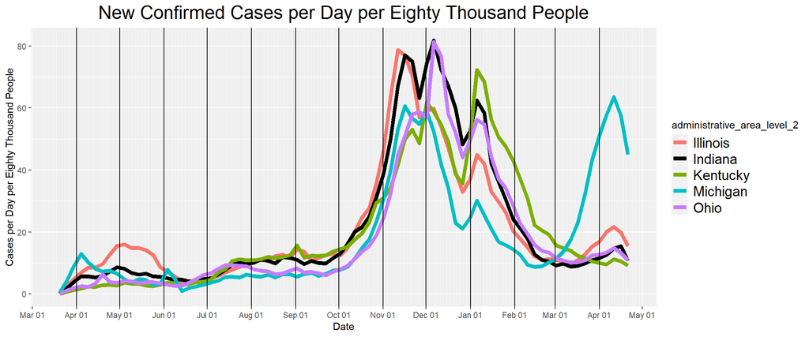

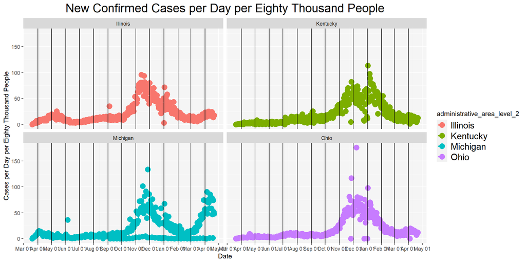

### Hospitalizations - States Neighboring Indiana

Because hospitalizations are smoother than cases or deaths, we present the data with line graphs below:

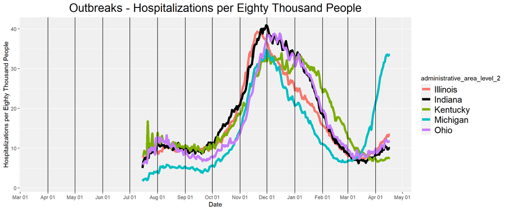

### Deaths - States Neighboring Indiana

The first plot is a comparison of smoothed weighted averages. The second is the actual data.

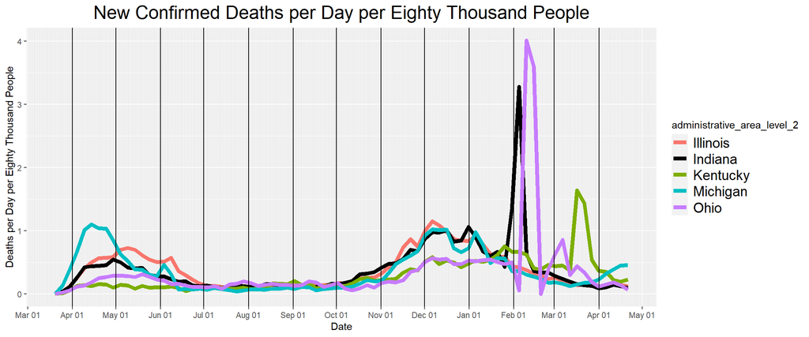

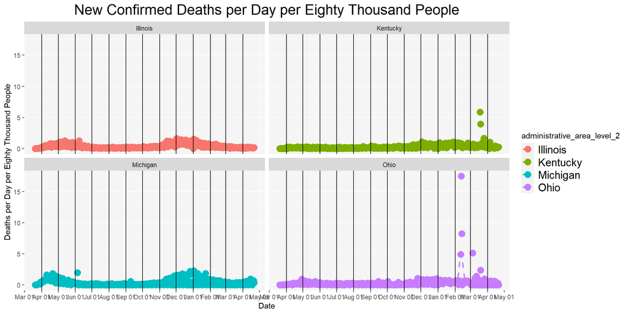

# US outbreaks by state

The coloring scheme for the map below is based on a combination of average hospitalizations and new deaths per captita in the past week. The coloring scheme is relative, it will always color the worst state pure red.

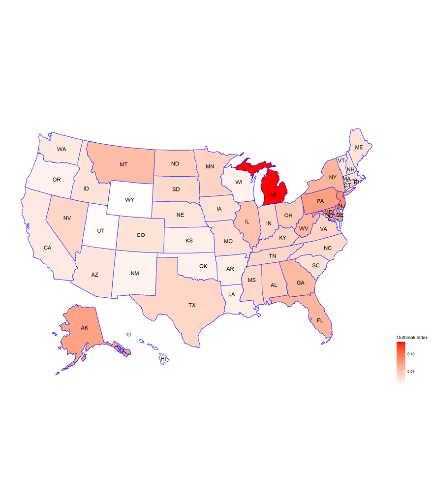

### Cases - Outbreaks in US

The first chart is a comparison of smoothed weighted averages. The second chart is the actual data.

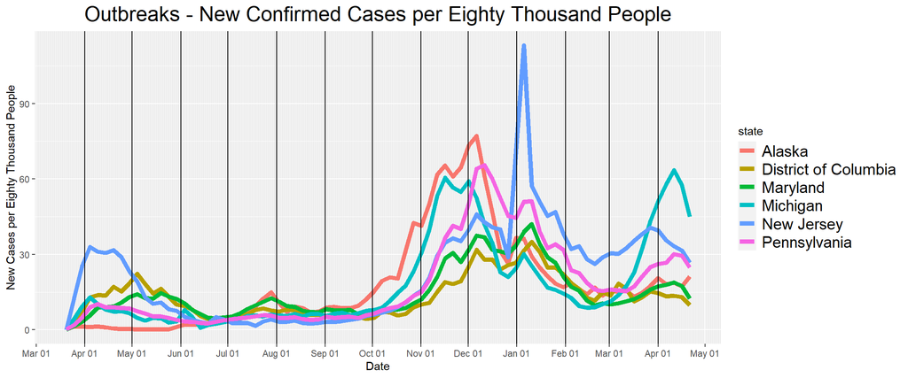

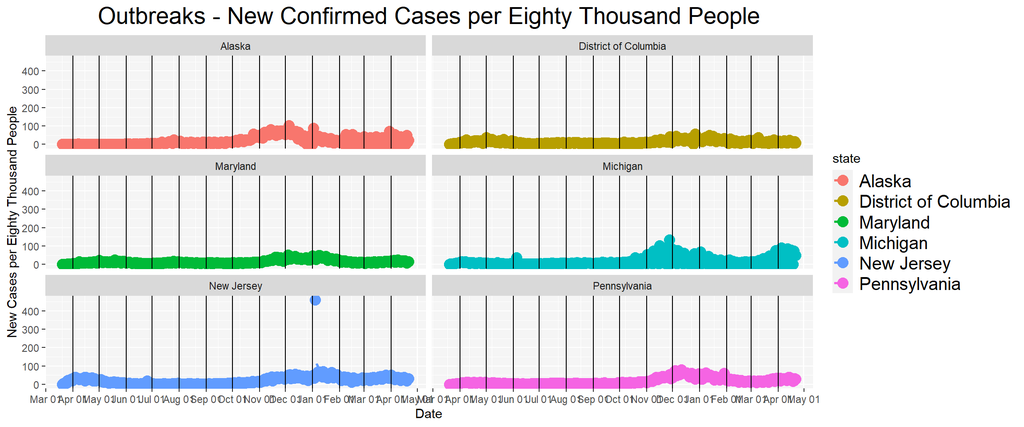

### Hospitalizations - Outbreaks in US

Because hospitalizations are smoother than cases or deaths, we present the data with line graphs below:

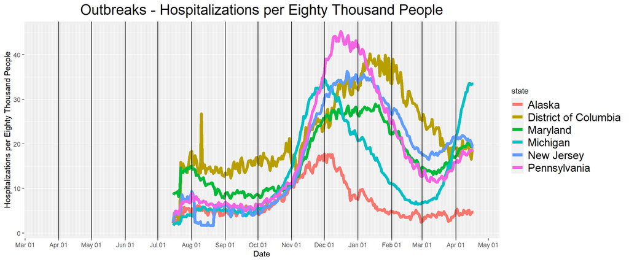

### Deaths - Outbreaks in US

The first chart is a comparison of smoothed weighted averages. The second chart is the actual data.

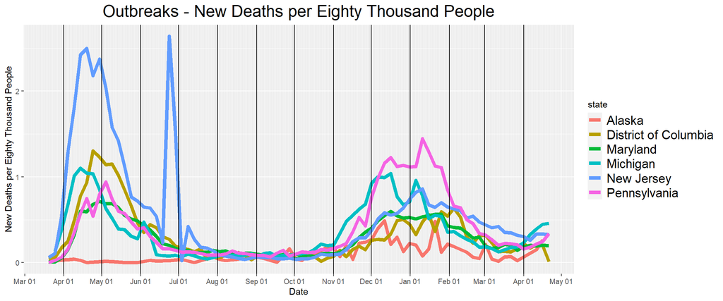

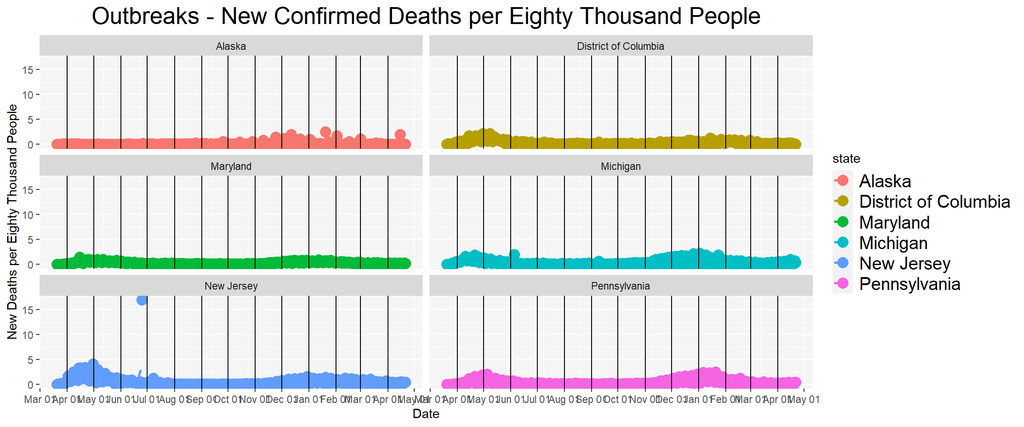

Data Sources:

Guidotti, Emanuele, and David Ardia. 2020. “COVID-19 Data Hub.” https://www.researchgate.net/project/COVID19-Data-Hub.

Smith, Mitch, Karen Yourish, Sarah Almukhtar, Keith Collins, Danielle Ivory, and Amy Harmon. 2020. “Coronavirus (covid-19) Data in the United States.” *The New York Times*. https://github.com/nytimes/covid-19-data.